# Balestriero & LeCun (2026)

*Proving and Improving the Platonic Representation Hypothesis with JEPAs*  
Optional reading · arXiv 2610.39302, 29 Oct 2026 · preprint, not peer-reviewed

11 November 2026

## The terms we need

**JEPA** (Joint-Embedding Predictive Architecture): an encoder trained so that

- the embeddings of a *positive pair* match,
- while a second term keeps all embeddings from collapsing to one point.

**Positive pair:** two inputs the objective declares to be views of the same thing.

**Good views:** two observations of one scene  
two photos of it · two captions of one image

**Bad views:** two corruptions of one observation  
two crops of one photo · two masked copies of one text

## The theorem (Fig. 1, left)

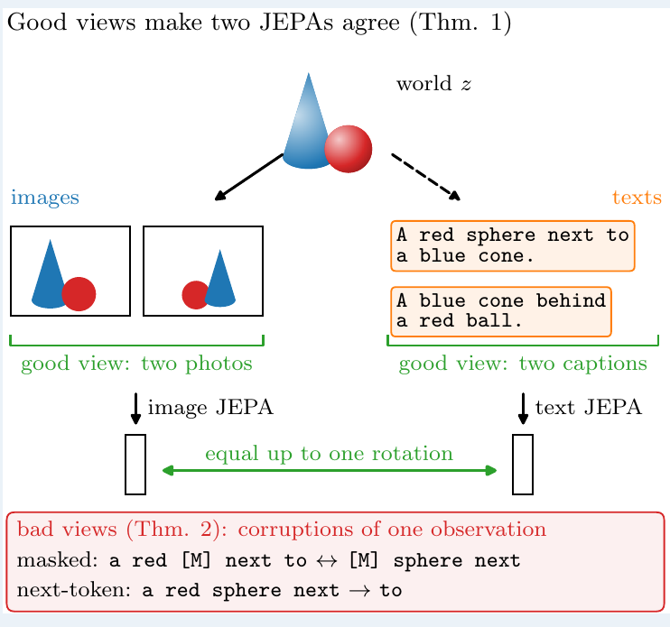

“We turn the hypothesis into a theorem.”

**If**

- the world is finite, and each modality renders it **injectively**,
- every modality is trained with the same objective and embedding dimension, to its optimum,
- all modalities share **one positive-pair distribution**,
- the optimum is unique up to rotation,

**then** every modality learns the same embedding of the world, **up to one rotation**.

“The proof is direct”, in their words.  
So where is the work done?

## Bad views, and next-token prediction

Two corruptions of one observation share its *nuisance*: word choice, viewpoint, lighting.  
**If** it outweighs the weakest world direction that the embedding needs,  
the encoder spends dimensions on the nuisance,  
and no rotation aligns those with another modality.

**Next-token prediction is a bad-view JEPA:**  
its positives are a prefix and its continuation, inside one document.

- Their explanation of why language models align with vision “only through scale”.
- Applied “heuristically”: “a prediction to test rather than a corollary”.

By their own definition, DINOv2 is a bad-view JEPA too:  
its positives are crops of one photo.

## The evidence (Fig. 1, right)

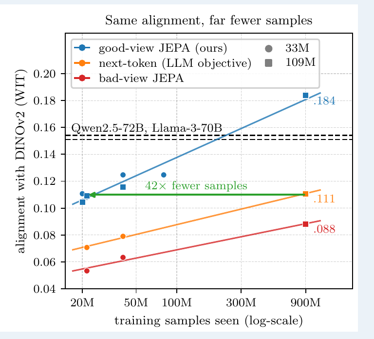

Huh et al.’s benchmark: WIT-1024, mutual 10-NN, against DINOv2.

- 109M-parameter text JEPA, good views: **.184**  
  (3 seeds; a 4th seed reached .121; mean of all 4: .168)
- largest language model tested (Qwen2.5-72B): .154
- CLIP’s text encoder: .124

Same corpus and encoder:  
good views match next-token’s .111  
with **42 times fewer samples**  
(14 times fewer text tokens).

A scaling law of alignment (measured as Flickr retrieval) predicted 85 new runs before they were trained.

## Caveats

**Theirs:**

- “No experiment meets the hypotheses of Theorem 1 exactly.”
- “Real modalities are lossy.” The theorem needs injective renderings.
- “The main caveat is where good views come from”: two of each image’s three training texts were written by an image captioner that “sees images through CLIP ViT-L/14”.  
  Small-model ablation: without the captioner, .060 instead of .107.
- “Paired information thus enters through the definition of positives, one fitted linear map and, on Recap, captioner-generated texts, never through a cross-modal loss.”

**Ours:** the language models were trained on other corpora, with other recipes.

## For discussion

**Huh et al.:** scale and task diversity drive convergence (§3).

**Balestriero & LeCun:** “The PRH is a statement about positive views.”

**Is this still the same hypothesis?** Show of hands:

- the same hypothesis
- a special case of it
- a different hypothesis

Who decides that two captions describe one scene?  
Where did that information come from?